# Risk Factor Analysis

## Outcome Variable

**Outcome Variable:** sstunted

## Predictor Variables

**Intervention Variable:** nhh

**Adjustment Set:**

unadjusted

## Stratifying Variables

The analysis was stratified on these variable(s):

- agecat
- studyid
- country

## Data Summary

| agecat | studyid | country | A | n | nA | nAY0 | nAY1 |
| --- | --- | --- | --- | --- | --- | --- | --- |
| Birth | ki1000108-IRC | INDIA | 3 or less | 388 | 54 | 53 | 1 |
| Birth | ki1000108-IRC | INDIA | 4-5 | 388 | 150 | 142 | 8 |
| Birth | ki1000108-IRC | INDIA | 6-7 | 388 | 103 | 97 | 6 |
| Birth | ki1000108-IRC | INDIA | 8+ | 388 | 81 | 80 | 1 |
| Birth | ki1017093-NIH-Birth | BANGLADESH | 3 or less | 28 | 7 | 7 | 0 |
| Birth | ki1017093-NIH-Birth | BANGLADESH | 4-5 | 28 | 11 | 11 | 0 |
| Birth | ki1017093-NIH-Birth | BANGLADESH | 6-7 | 28 | 7 | 7 | 0 |
| Birth | ki1017093-NIH-Birth | BANGLADESH | 8+ | 28 | 3 | 3 | 0 |
| Birth | ki1017093c-NIH-Crypto | BANGLADESH | 3 or less | 27 | 8 | 8 | 0 |
| Birth | ki1017093c-NIH-Crypto | BANGLADESH | 4-5 | 27 | 9 | 9 | 0 |
| Birth | ki1017093c-NIH-Crypto | BANGLADESH | 6-7 | 27 | 7 | 6 | 1 |
| Birth | ki1017093c-NIH-Crypto | BANGLADESH | 8+ | 27 | 3 | 3 | 0 |
| 3 months | ki1000108-IRC | INDIA | 3 or less | 407 | 58 | 55 | 3 |
| 3 months | ki1000108-IRC | INDIA | 4-5 | 407 | 156 | 137 | 19 |
| 3 months | ki1000108-IRC | INDIA | 6-7 | 407 | 106 | 99 | 7 |
| 3 months | ki1000108-IRC | INDIA | 8+ | 407 | 87 | 80 | 7 |
| 3 months | ki1000304b-SAS-FoodSuppl | INDIA | 3 or less | 97 | 7 | 5 | 2 |
| 3 months | ki1000304b-SAS-FoodSuppl | INDIA | 4-5 | 97 | 36 | 32 | 4 |
| 3 months | ki1000304b-SAS-FoodSuppl | INDIA | 6-7 | 97 | 35 | 30 | 5 |
| 3 months | ki1000304b-SAS-FoodSuppl | INDIA | 8+ | 97 | 19 | 17 | 2 |
| 3 months | ki1017093-NIH-Birth | BANGLADESH | 3 or less | 570 | 101 | 94 | 7 |
| 3 months | ki1017093-NIH-Birth | BANGLADESH | 4-5 | 570 | 241 | 224 | 17 |
| 3 months | ki1017093-NIH-Birth | BANGLADESH | 6-7 | 570 | 133 | 126 | 7 |
| 3 months | ki1017093-NIH-Birth | BANGLADESH | 8+ | 570 | 95 | 93 | 2 |
| 3 months | ki1017093b-PROVIDE | BANGLADESH | 3 or less | 645 | 126 | 123 | 3 |
| 3 months | ki1017093b-PROVIDE | BANGLADESH | 4-5 | 645 | 298 | 293 | 5 |
| 3 months | ki1017093b-PROVIDE | BANGLADESH | 6-7 | 645 | 136 | 135 | 1 |
| 3 months | ki1017093b-PROVIDE | BANGLADESH | 8+ | 645 | 85 | 84 | 1 |
| 3 months | ki1017093c-NIH-Crypto | BANGLADESH | 3 or less | 728 | 109 | 105 | 4 |
| 3 months | ki1017093c-NIH-Crypto | BANGLADESH | 4-5 | 728 | 330 | 312 | 18 |

[output cut: 118 more lines]

The following strata were considered:

- agecat: 12 months, studyid: ki1000108-IRC, country: INDIA
- agecat: 12 months, studyid: ki1000304b-SAS-FoodSuppl, country: INDIA
- agecat: 12 months, studyid: ki1017093-NIH-Birth, country: BANGLADESH
- agecat: 12 months, studyid: ki1017093b-PROVIDE, country: BANGLADESH
- agecat: 12 months, studyid: ki1017093c-NIH-Crypto, country: BANGLADESH
- agecat: 12 months, studyid: ki1148112-LCNI-5, country: MALAWI
- agecat: 18 months, studyid: ki1000108-IRC, country: INDIA
- agecat: 18 months, studyid: ki1000304b-SAS-FoodSuppl, country: INDIA
- agecat: 18 months, studyid: ki1017093-NIH-Birth, country: BANGLADESH
- agecat: 18 months, studyid: ki1017093b-PROVIDE, country: BANGLADESH
- agecat: 18 months, studyid: ki1017093c-NIH-Crypto, country: BANGLADESH
- agecat: 18 months, studyid: ki1148112-LCNI-5, country: MALAWI
- agecat: 24 months, studyid: ki1000108-IRC, country: INDIA
- agecat: 24 months, studyid: ki1017093-NIH-Birth, country: BANGLADESH
- agecat: 24 months, studyid: ki1017093b-PROVIDE, country: BANGLADESH
- agecat: 24 months, studyid: ki1017093c-NIH-Crypto, country: BANGLADESH
- agecat: 24 months, studyid: ki1148112-LCNI-5, country: MALAWI
- agecat: 3 months, studyid: ki1000108-IRC, country: INDIA
- agecat: 3 months, studyid: ki1000304b-SAS-FoodSuppl, country: INDIA
- agecat: 3 months, studyid: ki1017093-NIH-Birth, country: BANGLADESH
- agecat: 3 months, studyid: ki1017093b-PROVIDE, country: BANGLADESH
- agecat: 3 months, studyid: ki1017093c-NIH-Crypto, country: BANGLADESH
- agecat: 6 months, studyid: ki1000108-IRC, country: INDIA
- agecat: 6 months, studyid: ki1000304b-SAS-FoodSuppl, country: INDIA
- agecat: 6 months, studyid: ki1017093-NIH-Birth, country: BANGLADESH
- agecat: 6 months, studyid: ki1017093b-PROVIDE, country: BANGLADESH
- agecat: 6 months, studyid: ki1017093c-NIH-Crypto, country: BANGLADESH
- agecat: 6 months, studyid: ki1148112-LCNI-5, country: MALAWI
- agecat: 9 months, studyid: ki1000108-IRC, country: INDIA
- agecat: 9 months, studyid: ki1000304b-SAS-FoodSuppl, country: INDIA
- agecat: 9 months, studyid: ki1017093-NIH-Birth, country: BANGLADESH
- agecat: 9 months, studyid: ki1017093b-PROVIDE, country: BANGLADESH
- agecat: 9 months, studyid: ki1017093c-NIH-Crypto, country: BANGLADESH
- agecat: 9 months, studyid: ki1148112-LCNI-5, country: MALAWI
- agecat: Birth, studyid: ki1000108-IRC, country: INDIA
- agecat: Birth, studyid: ki1017093-NIH-Birth, country: BANGLADESH
- agecat: Birth, studyid: ki1017093c-NIH-Crypto, country: BANGLADESH

### Dropped Strata

Some strata were dropped due to rare outcomes:

- agecat: Birth, studyid: ki1000108-IRC, country: INDIA
- agecat: Birth, studyid: ki1017093-NIH-Birth, country: BANGLADESH
- agecat: Birth, studyid: ki1017093c-NIH-Crypto, country: BANGLADESH
- agecat: 3 months, studyid: ki1000108-IRC, country: INDIA
- agecat: 3 months, studyid: ki1000304b-SAS-FoodSuppl, country: INDIA
- agecat: 3 months, studyid: ki1017093-NIH-Birth, country: BANGLADESH
- agecat: 3 months, studyid: ki1017093b-PROVIDE, country: BANGLADESH
- agecat: 3 months, studyid: ki1017093c-NIH-Crypto, country: BANGLADESH
- agecat: 6 months, studyid: ki1000108-IRC, country: INDIA
- agecat: 6 months, studyid: ki1000304b-SAS-FoodSuppl, country: INDIA
- agecat: 6 months, studyid: ki1017093-NIH-Birth, country: BANGLADESH
- agecat: 6 months, studyid: ki1017093b-PROVIDE, country: BANGLADESH
- agecat: 6 months, studyid: ki1017093c-NIH-Crypto, country: BANGLADESH
- agecat: 9 months, studyid: ki1000108-IRC, country: INDIA
- agecat: 9 months, studyid: ki1000304b-SAS-FoodSuppl, country: INDIA
- agecat: 9 months, studyid: ki1017093b-PROVIDE, country: BANGLADESH
- agecat: 9 months, studyid: ki1017093c-NIH-Crypto, country: BANGLADESH
- agecat: 9 months, studyid: ki1148112-LCNI-5, country: MALAWI
- agecat: 12 months, studyid: ki1000108-IRC, country: INDIA
- agecat: 12 months, studyid: ki1000304b-SAS-FoodSuppl, country: INDIA
- agecat: 12 months, studyid: ki1017093b-PROVIDE, country: BANGLADESH
- agecat: 12 months, studyid: ki1017093c-NIH-Crypto, country: BANGLADESH
- agecat: 18 months, studyid: ki1000108-IRC, country: INDIA
- agecat: 18 months, studyid: ki1000304b-SAS-FoodSuppl, country: INDIA
- agecat: 18 months, studyid: ki1017093c-NIH-Crypto, country: BANGLADESH
- agecat: 24 months, studyid: ki1000108-IRC, country: INDIA
- agecat: 24 months, studyid: ki1017093c-NIH-Crypto, country: BANGLADESH

## Methods Detail

We’re interested in the causal parameters $E[Y_a]$ for all values of $a \in \mathcal{A}$. These parameters represent the mean outcome if, possibly contrary to fact, we intervened to set all units to have $A=a$. Under the randomization and positivity assumptions, these are identified by the statistical parameters $\psi_a=E_W[E_{Y|A,W}(Y|A=a,W)]$. In addition, we’re interested in the mean of $Y$, $E[Y]$ under no intervention (the observed mean). We will estimate these parameters by using SuperLearner to fit the relevant likelihood factors – $E_{Y|A,W}(Y|A=a,W)$ and $p(A=a|W)$, and then updating our likelihood fit using a joint TMLE.

For unadjusted analyses ($W=\{\}$), initial likelihoods were estimated using Lrnr_glm to estimate the simple $E(Y|A)$ and Lrnr_mean to estimate $p(A)$. For adjusted analyses, a small library containing Lrnr_glmnet, Lrnr_xgboost, and Lrnr_mean was used.

Having estimated these parameters, we will then use the delta method to estimate relative risks and attributable risks relative to a prespecified baseline level of $A$.

# Results Detail

## Results Plots

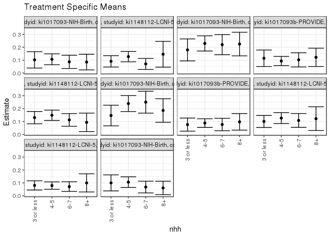

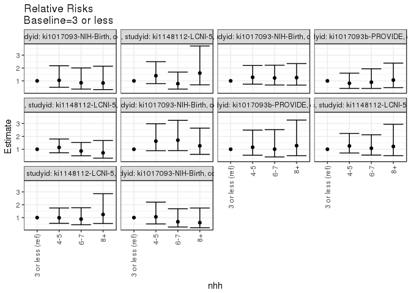

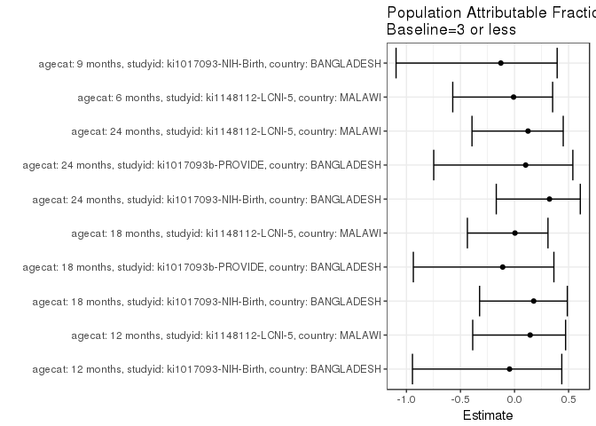

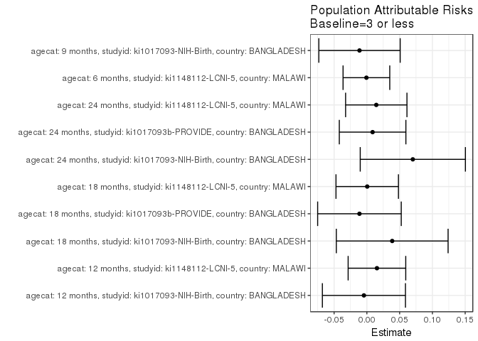

## Results Table

### Parameter: TSM

| agecat | studyid | country | intervention_level | baseline_level | estimate | ci_lower | ci_upper |
| --- | --- | --- | --- | --- | --- | --- | --- |
| 6 months | ki1148112-LCNI-5 | MALAWI | 3 or less | NA | 0.0803571 | 0.0447356 | 0.1159786 |
| 6 months | ki1148112-LCNI-5 | MALAWI | 4-5 | NA | 0.0794118 | 0.0506543 | 0.1081692 |
| 6 months | ki1148112-LCNI-5 | MALAWI | 6-7 | NA | 0.0714286 | 0.0339897 | 0.1088674 |
| 6 months | ki1148112-LCNI-5 | MALAWI | 8+ | NA | 0.1000000 | 0.0296787 | 0.1703213 |
| 9 months | ki1017093-NIH-Birth | BANGLADESH | 3 or less | NA | 0.1000000 | 0.0379593 | 0.1620407 |
| 9 months | ki1017093-NIH-Birth | BANGLADESH | 4-5 | NA | 0.1059908 | 0.0649938 | 0.1469878 |
| 9 months | ki1017093-NIH-Birth | BANGLADESH | 6-7 | NA | 0.0677966 | 0.0223925 | 0.1132007 |
| 9 months | ki1017093-NIH-Birth | BANGLADESH | 8+ | NA | 0.0609756 | 0.0091331 | 0.1128182 |
| 12 months | ki1017093-NIH-Birth | BANGLADESH | 3 or less | NA | 0.1022727 | 0.0389001 | 0.1656453 |
| 12 months | ki1017093-NIH-Birth | BANGLADESH | 4-5 | NA | 0.1067961 | 0.0645769 | 0.1490153 |
| 12 months | ki1017093-NIH-Birth | BANGLADESH | 6-7 | NA | 0.0869565 | 0.0354053 | 0.1385077 |
| 12 months | ki1017093-NIH-Birth | BANGLADESH | 8+ | NA | 0.0853659 | 0.0248248 | 0.1459069 |
| 12 months | ki1148112-LCNI-5 | MALAWI | 3 or less | NA | 0.0909091 | 0.0470092 | 0.1348090 |
| 12 months | ki1148112-LCNI-5 | MALAWI | 4-5 | NA | 0.1273408 | 0.0873235 | 0.1673582 |
| 12 months | ki1148112-LCNI-5 | MALAWI | 6-7 | NA | 0.0709220 | 0.0285182 | 0.1133258 |
| 12 months | ki1148112-LCNI-5 | MALAWI | 8+ | NA | 0.1458333 | 0.0459076 | 0.2457590 |
| 18 months | ki1017093-NIH-Birth | BANGLADESH | 3 or less | NA | 0.1794872 | 0.0942302 | 0.2647441 |
| 18 months | ki1017093-NIH-Birth | BANGLADESH | 4-5 | NA | 0.2295918 | 0.1706494 | 0.2885343 |
| 18 months | ki1017093-NIH-Birth | BANGLADESH | 6-7 | NA | 0.2201835 | 0.1423094 | 0.2980576 |
| 18 months | ki1017093-NIH-Birth | BANGLADESH | 8+ | NA | 0.2250000 | 0.1333959 | 0.3166041 |
| 18 months | ki1017093b-PROVIDE | BANGLADESH | 3 or less | NA | 0.1145833 | 0.0508098 | 0.1783569 |
| 18 months | ki1017093b-PROVIDE | BANGLADESH | 4-5 | NA | 0.0933852 | 0.0577790 | 0.1289914 |
| 18 months | ki1017093b-PROVIDE | BANGLADESH | 6-7 | NA | 0.1025641 | 0.0475406 | 0.1575876 |
| 18 months | ki1017093b-PROVIDE | BANGLADESH | 8+ | NA | 0.1219512 | 0.0510608 | 0.1928416 |
| 18 months | ki1148112-LCNI-5 | MALAWI | 3 or less | NA | 0.1302083 | 0.0825733 | 0.1778434 |
| 18 months | ki1148112-LCNI-5 | MALAWI | 4-5 | NA | 0.1485149 | 0.1084464 | 0.1885833 |
| 18 months | ki1148112-LCNI-5 | MALAWI | 6-7 | NA | 0.1125000 | 0.0635051 | 0.1614949 |
| 18 months | ki1148112-LCNI-5 | MALAWI | 8+ | NA | 0.0937500 | 0.0222889 | 0.1652112 |
| 24 months | ki1017093-NIH-Birth | BANGLADESH | 3 or less | NA | 0.1466667 | 0.0665082 | 0.2268251 |
| 24 months | ki1017093-NIH-Birth | BANGLADESH | 4-5 | NA | 0.2391304 | 0.1774257 | 0.3008352 |
| 24 months | ki1017093-NIH-Birth | BANGLADESH | 6-7 | NA | 0.2500000 | 0.1650320 | 0.3349680 |
| 24 months | ki1017093-NIH-Birth | BANGLADESH | 8+ | NA | 0.1857143 | 0.0945097 | 0.2769189 |
| 24 months | ki1017093b-PROVIDE | BANGLADESH | 3 or less | NA | 0.0761905 | 0.0254012 | 0.1269797 |
| 24 months | ki1017093b-PROVIDE | BANGLADESH | 4-5 | NA | 0.0879121 | 0.0542930 | 0.1215312 |
| 24 months | ki1017093b-PROVIDE | BANGLADESH | 6-7 | NA | 0.0769231 | 0.0285973 | 0.1252489 |
| 24 months | ki1017093b-PROVIDE | BANGLADESH | 8+ | NA | 0.0975610 | 0.0332826 | 0.1618393 |
| 24 months | ki1148112-LCNI-5 | MALAWI | 3 or less | NA | 0.1006289 | 0.0538275 | 0.1474304 |
| 24 months | ki1148112-LCNI-5 | MALAWI | 4-5 | NA | 0.1265823 | 0.0842131 | 0.1689515 |
| 24 months | ki1148112-LCNI-5 | MALAWI | 6-7 | NA | 0.1085271 | 0.0548048 | 0.1622495 |
| 24 months | ki1148112-LCNI-5 | MALAWI | 8+ | NA | 0.1224490 | 0.0305856 | 0.2143124 |

### Parameter: E(Y)

| agecat | studyid | country | intervention_level | baseline_level | estimate | ci_lower | ci_upper |
| --- | --- | --- | --- | --- | --- | --- | --- |
| 6 months | ki1148112-LCNI-5 | MALAWI | NA | NA | 0.0796569 | 0.0791677 | 0.0801460 |
| 9 months | ki1017093-NIH-Birth | BANGLADESH | NA | NA | 0.0887574 | 0.0870664 | 0.0904484 |
| 12 months | ki1017093-NIH-Birth | BANGLADESH | NA | NA | 0.0977597 | 0.0969155 | 0.0986038 |
| 12 months | ki1148112-LCNI-5 | MALAWI | NA | NA | 0.1062802 | 0.1042606 | 0.1082997 |
| 18 months | ki1017093-NIH-Birth | BANGLADESH | NA | NA | 0.2181425 | 0.2165208 | 0.2197643 |
| 18 months | ki1017093b-PROVIDE | BANGLADESH | NA | NA | 0.1032609 | 0.1023474 | 0.1041744 |
| 18 months | ki1148112-LCNI-5 | MALAWI | NA | NA | 0.1307371 | 0.1294103 | 0.1320640 |
| 24 months | ki1017093-NIH-Birth | BANGLADESH | NA | NA | 0.2167832 | 0.2131282 | 0.2204382 |
| 24 months | ki1017093b-PROVIDE | BANGLADESH | NA | NA | 0.0849220 | 0.0843231 | 0.0855209 |
| 24 months | ki1148112-LCNI-5 | MALAWI | NA | NA | 0.1149826 | 0.1140608 | 0.1159044 |

### Parameter: RR

| agecat | studyid | country | intervention_level | baseline_level | estimate | ci_lower | ci_upper |
| --- | --- | --- | --- | --- | --- | --- | --- |
| 6 months | ki1148112-LCNI-5 | MALAWI | 3 or less | 3 or less | 1.0000000 | 1.0000000 | 1.000000 |
| 6 months | ki1148112-LCNI-5 | MALAWI | 4-5 | 3 or less | 0.9882353 | 0.5575312 | 1.751667 |
| 6 months | ki1148112-LCNI-5 | MALAWI | 6-7 | 3 or less | 0.8888889 | 0.4474248 | 1.765936 |
| 6 months | ki1148112-LCNI-5 | MALAWI | 8+ | 3 or less | 1.2444444 | 0.5419491 | 2.857541 |
| 9 months | ki1017093-NIH-Birth | BANGLADESH | 3 or less | 3 or less | 1.0000000 | 1.0000000 | 1.000000 |
| 9 months | ki1017093-NIH-Birth | BANGLADESH | 4-5 | 3 or less | 1.0599078 | 0.5102140 | 2.201830 |
| 9 months | ki1017093-NIH-Birth | BANGLADESH | 6-7 | 3 or less | 0.6779661 | 0.2721029 | 1.689207 |
| 9 months | ki1017093-NIH-Birth | BANGLADESH | 8+ | 3 or less | 0.6097561 | 0.2128419 | 1.746848 |
| 12 months | ki1017093-NIH-Birth | BANGLADESH | 3 or less | 3 or less | 1.0000000 | 1.0000000 | 1.000000 |
| 12 months | ki1017093-NIH-Birth | BANGLADESH | 4-5 | 3 or less | 1.0442287 | 0.5007082 | 2.177742 |
| 12 months | ki1017093-NIH-Birth | BANGLADESH | 6-7 | 3 or less | 0.8502415 | 0.3606676 | 2.004368 |
| 12 months | ki1017093-NIH-Birth | BANGLADESH | 8+ | 3 or less | 0.8346883 | 0.3254786 | 2.140554 |
| 12 months | ki1148112-LCNI-5 | MALAWI | 3 or less | 3 or less | 1.0000000 | 1.0000000 | 1.000000 |
| 12 months | ki1148112-LCNI-5 | MALAWI | 4-5 | 3 or less | 1.4007491 | 0.7873038 | 2.492174 |
| 12 months | ki1148112-LCNI-5 | MALAWI | 6-7 | 3 or less | 0.7801418 | 0.3617402 | 1.682482 |
| 12 months | ki1148112-LCNI-5 | MALAWI | 8+ | 3 or less | 1.6041667 | 0.6937347 | 3.709416 |
| 18 months | ki1017093-NIH-Birth | BANGLADESH | 3 or less | 3 or less | 1.0000000 | 1.0000000 | 1.000000 |
| 18 months | ki1017093-NIH-Birth | BANGLADESH | 4-5 | 3 or less | 1.2791545 | 0.7454688 | 2.194909 |
| 18 months | ki1017093-NIH-Birth | BANGLADESH | 6-7 | 3 or less | 1.2267366 | 0.6785105 | 2.217921 |
| 18 months | ki1017093-NIH-Birth | BANGLADESH | 8+ | 3 or less | 1.2535714 | 0.6705825 | 2.343398 |
| 18 months | ki1017093b-PROVIDE | BANGLADESH | 3 or less | 3 or less | 1.0000000 | 1.0000000 | 1.000000 |
| 18 months | ki1017093b-PROVIDE | BANGLADESH | 4-5 | 3 or less | 0.8149982 | 0.4151088 | 1.600116 |
| 18 months | ki1017093b-PROVIDE | BANGLADESH | 6-7 | 3 or less | 0.8951049 | 0.4131903 | 1.939089 |
| 18 months | ki1017093b-PROVIDE | BANGLADESH | 8+ | 3 or less | 1.0643016 | 0.4759382 | 2.380010 |
| 18 months | ki1148112-LCNI-5 | MALAWI | 3 or less | 3 or less | 1.0000000 | 1.0000000 | 1.000000 |
| 18 months | ki1148112-LCNI-5 | MALAWI | 4-5 | 3 or less | 1.1405941 | 0.7239653 | 1.796985 |
| 18 months | ki1148112-LCNI-5 | MALAWI | 6-7 | 3 or less | 0.8640000 | 0.4892125 | 1.525914 |
| 18 months | ki1148112-LCNI-5 | MALAWI | 8+ | 3 or less | 0.7200000 | 0.3091276 | 1.676978 |
| 24 months | ki1017093-NIH-Birth | BANGLADESH | 3 or less | 3 or less | 1.0000000 | 1.0000000 | 1.000000 |
| 24 months | ki1017093-NIH-Birth | BANGLADESH | 4-5 | 3 or less | 1.6304348 | 0.8908845 | 2.983908 |
| 24 months | ki1017093-NIH-Birth | BANGLADESH | 6-7 | 3 or less | 1.7045455 | 0.8955693 | 3.244277 |
| 24 months | ki1017093-NIH-Birth | BANGLADESH | 8+ | 3 or less | 1.2662338 | 0.6073080 | 2.640090 |
| 24 months | ki1017093b-PROVIDE | BANGLADESH | 3 or less | 3 or less | 1.0000000 | 1.0000000 | 1.000000 |
| 24 months | ki1017093b-PROVIDE | BANGLADESH | 4-5 | 3 or less | 1.1538462 | 0.5350416 | 2.488332 |
| 24 months | ki1017093b-PROVIDE | BANGLADESH | 6-7 | 3 or less | 1.0096154 | 0.4039656 | 2.523292 |
| 24 months | ki1017093b-PROVIDE | BANGLADESH | 8+ | 3 or less | 1.2804878 | 0.5015670 | 3.269053 |
| 24 months | ki1148112-LCNI-5 | MALAWI | 3 or less | 3 or less | 1.0000000 | 1.0000000 | 1.000000 |
| 24 months | ki1148112-LCNI-5 | MALAWI | 4-5 | 3 or less | 1.2579114 | 0.7092413 | 2.231034 |
| 24 months | ki1148112-LCNI-5 | MALAWI | 6-7 | 3 or less | 1.0784884 | 0.5468044 | 2.127154 |
| 24 months | ki1148112-LCNI-5 | MALAWI | 8+ | 3 or less | 1.2168367 | 0.5033692 | 2.941562 |

### Parameter: PAR

| agecat | studyid | country | intervention_level | baseline_level | estimate | ci_lower | ci_upper |
| --- | --- | --- | --- | --- | --- | --- | --- |
| 6 months | ki1148112-LCNI-5 | MALAWI | 3 or less | NA | -0.0007003 | -0.0363251 | 0.0349246 |
| 9 months | ki1017093-NIH-Birth | BANGLADESH | 3 or less | NA | -0.0112426 | -0.0733064 | 0.0508212 |
| 12 months | ki1017093-NIH-Birth | BANGLADESH | 3 or less | NA | -0.0045131 | -0.0678913 | 0.0588652 |
| 12 months | ki1148112-LCNI-5 | MALAWI | 3 or less | NA | 0.0153711 | -0.0285752 | 0.0593174 |
| 18 months | ki1017093-NIH-Birth | BANGLADESH | 3 or less | NA | 0.0386554 | -0.0466170 | 0.1239277 |
| 18 months | ki1017093b-PROVIDE | BANGLADESH | 3 or less | NA | -0.0113225 | -0.0751026 | 0.0524577 |
| 18 months | ki1148112-LCNI-5 | MALAWI | 3 or less | NA | 0.0005288 | -0.0471247 | 0.0481823 |
| 24 months | ki1017093-NIH-Birth | BANGLADESH | 3 or less | NA | 0.0701166 | -0.0101252 | 0.1503583 |
| 24 months | ki1017093b-PROVIDE | BANGLADESH | 3 or less | NA | 0.0087315 | -0.0420612 | 0.0595243 |
| 24 months | ki1148112-LCNI-5 | MALAWI | 3 or less | NA | 0.0143536 | -0.0324569 | 0.0611641 |

### Parameter: PAF

| agecat | studyid | country | intervention_level | baseline_level | estimate | ci_lower | ci_upper |
| --- | --- | --- | --- | --- | --- | --- | --- |
| 6 months | ki1148112-LCNI-5 | MALAWI | 3 or less | NA | -0.0087912 | -0.5715857 | 0.3524631 |
| 9 months | ki1017093-NIH-Birth | BANGLADESH | 3 or less | NA | -0.1266667 | -1.0958581 | 0.3943398 |
| 12 months | ki1017093-NIH-Birth | BANGLADESH | 3 or less | NA | -0.0461648 | -0.9441684 | 0.4370546 |
| 12 months | ki1148112-LCNI-5 | MALAWI | 3 or less | NA | 0.1446281 | -0.3868757 | 0.4724393 |
| 18 months | ki1017093-NIH-Birth | BANGLADESH | 3 or less | NA | 0.1772023 | -0.3231511 | 0.4883457 |
| 18 months | ki1017093b-PROVIDE | BANGLADESH | 3 or less | NA | -0.1096491 | -0.9361154 | 0.3640249 |
| 18 months | ki1148112-LCNI-5 | MALAWI | 3 or less | NA | 0.0040448 | -0.4360913 | 0.3092871 |
| 24 months | ki1017093-NIH-Birth | BANGLADESH | 3 or less | NA | 0.3234409 | -0.1688957 | 0.6084062 |
| 24 months | ki1017093b-PROVIDE | BANGLADESH | 3 or less | NA | 0.1028183 | -0.7474353 | 0.5393620 |
| 24 months | ki1148112-LCNI-5 | MALAWI | 3 or less | NA | 0.1248332 | -0.3934984 | 0.4503640 |